# Informe 2 - Estadística Inferencial

Carlos Santana Flores

# Gasto Público por Estudiante en Educación Básica: Un Estudio Regional en el Perú (2009-2022)

El presente informe estadístico tiene como objetivo **analizar el gasto anual en educación básica** –que abarca los niveles de inicial, primaria y secundaria– que el gobierno central de la República del Perú ha venido asumiendo a lo largo del período 2009-2022. Este análisis se fundamenta en una base de datos organizada por departamentos del país y se sustenta en información proveniente del Ministerio de Economía y Finanzas (MEF), con el respaldo metodológico y las cifras recopiladas por el Instituto Nacional de Estadística e Informática [INEI - Publicaciones](https://www.inei.gob.pe/estadisticas/indice-tematico/sociales/). De esta manera, se busca ofrecer una visión integral de la evolución del gasto público por estudiante de educación básica, identificando tendencias, brechas y posibles factores que hayan influido en su comportamiento a lo largo del tiempo.

[figure not shown]

La elección del período 2009-2022 permite evaluar dinámicas de corto y mediano plazo, al tiempo que la desagregación por departamentos posibilita examinar las disparidades regionales existentes. La información obtenida, producto del procesamiento y sistematización de datos oficiales, facilitará no solo la comprensión del panorama actual del financiamiento educativo, sino también la formulación de recomendaciones y lineamientos para la toma de decisiones informadas en el sector. Así, este estudio busca contribuir al debate sobre la inversión en educación, en aras de optimizar el uso de los recursos públicos y promover una enseñanza de mayor calidad en el territorio nacional.

### Información recopilada

La base de datos se obtuvo del portal de publicaciones de la página web de la INEI el formato presentado es un *data panel* con extensión EXCEL que consta de variables como los departamentos del Perú, nivel educativo y el gasto anual que incurre le gobierno central por el año escolar de un estudiante. Por cuestiones académicas se simularon tres variables (Infraestructura, Gasto en tecnología y Relación alumno docente) que se encuentran en la base de datos.

### Datos

| Departamento | nivel_educativo | Gasto_2022 | infraestructura | gasto_tecnologia | relacion_alumno_docente |
| --- | --- | --- | --- | --- | --- |
| Amazonas | Secundaria | 4844 | 3.588198 | 769.2912 | 33.96775 |
| Áncash | Secundaria | 7732 | 8.094746 | 1305.3812 | 13.65698 |
| Apurímac | Secundaria | 7178 | 4.680792 | 774.0177 | 26.82844 |
| Arequipa | Secundaria | 5602 | 8.947157 | 444.9261 | 16.19594 |
| Ayacucho | Secundaria | 7022 | 9.464206 | 1703.5712 | 13.82595 |
| Cajamarca | Secundaria | 4852 | 1.410008 | 1118.1910 | 32.59924 |

### Análisis descriptivo

Medidas descriptivas del gasto anual por estudiante según nivel educativo

| Nivel educativo | n | Media | Desviación estándar | Mediana | Mínimo | Máximo | Rango | Coef Asimetría | Curtosis |
| --- | --- | --- | --- | --- | --- | --- | --- | --- | --- |
| Inicial | 26 | 3698.69 | 916.62 | 3424 | 2535 | 5862 | 3327 | 0.78 | -0.53 |
| Primaria | 26 | 3869.58 | 1098.02 | 3533 | 2246 | 6535 | 4289 | 0.54 | -0.54 |
| Secundaria | 26 | 5337.31 | 1744.48 | 4848 | 2852 | 9921 | 7069 | 0.76 | -0.18 |

### Prueba de hipótesis para una media

El responsable de la Dirección de Planificación Presupuestaría para la Educación Básica del MEF desea saber si el gasto promedio anual de un estudiante de educación inicial en el Perú supera los 3300 soles.

- Planteamiento de hipótesis

Ho: Promedio < = 3300

H1: Promedio > 3300

- Nivel de sinificancia

alfa = 0.05

- Estadístico de prueba:

t = 2.22

- Decisión estadística:

p-value = 0.018 < 0.05 = alfa; Se rechaza Ho

- Conclusión estadística:

A un nivel de significancia de 5% se puede afirmar que el gasto promedio anual de un estudiante de educación inicial en el Perú supera los 3300 soles.

Resultados de la prueba t para una media

| Media muestral | Estadístico t | p-valor | gl | IC inferior | IC superior | Método | Tipo prueba |
| --- | --- | --- | --- | --- | --- | --- | --- |
| 3698.692 | 2.217863 | 0.0179397 | 25 | 3391.63 | Inf | One Sample t-test | greater |

### Prueba de hipótesis para la diferencia de medias independientes

El responsable de la Dirección de Planificación Presupuestaría para Educación Básica del MEF desea saber si el gasto promedio anual de un estudiante de educación primaria en el Perú supera al gasto promedio anual de un estudiante de educación inicial. Asumiendo normalidad de las variables y varianzas homogéneas.

- Nivel de sinificancia

alfa = 0.05

- Estadístico de prueba:

t = 0.609

- Decisión estadística:

p-value = 0.273 > 0.05 = alfa; No se rechaza Ho

- Conclusión estadística:

A un nivel de significancia de 5% no se puede afirmar que el gasto promedio anual de un estudiante de educación primaria en el Perú supera al gasto promedio anual de un estudiante de educación inicial

Resultados de la prueba t para la diferencia de medias

| Media difer | Media muestral 1 | Media muestral 2 | Estadístico t | p-valor | gl | IC inferior | IC superior | Método | Tipo prueba |
| --- | --- | --- | --- | --- | --- | --- | --- | --- | --- |
| 170.8846 | 3869.577 | 3698.692 | 0.6091927 | 0.2725775 | 50 | -299.2235 | Inf | Two Sample t-test | greater |

### Prueba de hipótesis para la diferencia de medias muestras relacionadas

El responsable de la Dirección de Planificación Presupuestaría para Educación Básica del MEF desea saber si el gasto promedio anual de un estudiante de educación básica en el Perú para el año 2022 supera al gasto promedio anual de un estudiante de educación básica en el 2020.

- Planteamiento de hipótesis

Ho: Promedio_2022 < = Promedio_2020

H1: Promedio_2022 > Promedio_2020

- Nivel de sinificancia

alfa = 0.05

- Estadístico de prueba:

t = 7.20

- Decisión estadística:

p-value = 0.00 < 0.05 = alfa; Se rechaza Ho

Resultados de la prueba t para la diferencia de medias de muestras relacionadas

| Media difer | Estadístico t | p-valor | gl | IC inferior | IC superior | Método | Tipo prueba |
| --- | --- | --- | --- | --- | --- | --- | --- |
| 574.7342 | 7.203161 | 0 | 77 | 441.8945 | Inf | Paired t-test | greater |

### Prueba de hipótesis para una proporción

El responsable de la Dirección de Planificación Presupuestaría para la Educación Básica del MEF desea saber si el porcentaje de estudiantes que culminan satisfactoriamente el año escolar supera 80%.

- Planteamiento de hipótesis

Ho: Proporción < = 0.80

H1: Proporción > 0.80

- Nivel de sinificancia

alfa = 0.05

- Estadístico de prueba:

Z = 1.08

- Decisión estadística:

p-value = 0.149 > 0.05 = alfa; No se rechaza Ho

- Conclusión estadística:

A un nivel de significancia de 5% no se puede afirmar que el porcentaje de estudiantes que culminan satisfactoriamente el año escolar supera 80%.

Resultados de la prueba t para el análisis económico

| Proporción muestral | Estadístico Z | p-valor | gl | IC inferior | IC superior | Método | Tipo |
| --- | --- | --- | --- | --- | --- | --- | --- |
| 0.8 | 1.08 | 0.1493488 | 1 | 0.7212471 | 1 | 1-sample proportions test with continuity correction | greater |

### Análisis de varianza - DCA

El responsable de la Dirección de Planificación Presupuestaría para Educación Básica del MEF desea saber si existe diferencia significativa entre el gasto promedio anual en la educación de un estudiante por nivel educativo.

- Planteamiento de hipótesis

Ho: Promedio_inicial = Promedio_primaria = Promedio_secundaria

H1: Al menos uno de los promedios es diferente a los demás.

- Nivel de sinificancia

alfa = 0.05

- Estadístico de prueba:

F = 12.4

- Decisión estadística:

p-value = 0.00002 < 0.05 = alfa; Se rechaza Ho

- Conclusión estadística:

A un nivel de significancia de 5% se puede afirmar que existe diferencia significativa entre el gasto promedio anual en la educación de un estudiante por nivel educativo.

Tabla ANOVA

| Efecto | gl | Suma cuadrados | Cuadrado medio | Estadístico F | p-value |
| --- | --- | --- | --- | --- | --- |
| `Nivel educativo` | 2 | 42193628 | 21096814 | 12.43661 | 2.16e-05 |
| Residuals | 75 | 127226045 | 1696347 | NA | NA |

Comparaciones múltiples de Tukey

| Factor | Contraste | Valores nulos | Estimación | Límite Inf | Límite Sup | p-value Adj |
| --- | --- | --- | --- | --- | --- | --- |
| Nivel_educativo | Primaria-Inicial | 0 | 170.8846 | -692.8612 | 1034.630 | 0.8841591 |
| Nivel_educativo | Secundaria-Inicial | 0 | 1638.6154 | 774.8696 | 2502.361 | 0.0000629 |
| Nivel_educativo | Secundaria-Primaria | 0 | 1467.7308 | 603.9850 | 2331.477 | 0.0003442 |

Se concluye a partir de la tabla de comparaciones múltiples de Tukey que el mayor gasto promedio se da para los estudiantes de educación secundaria.

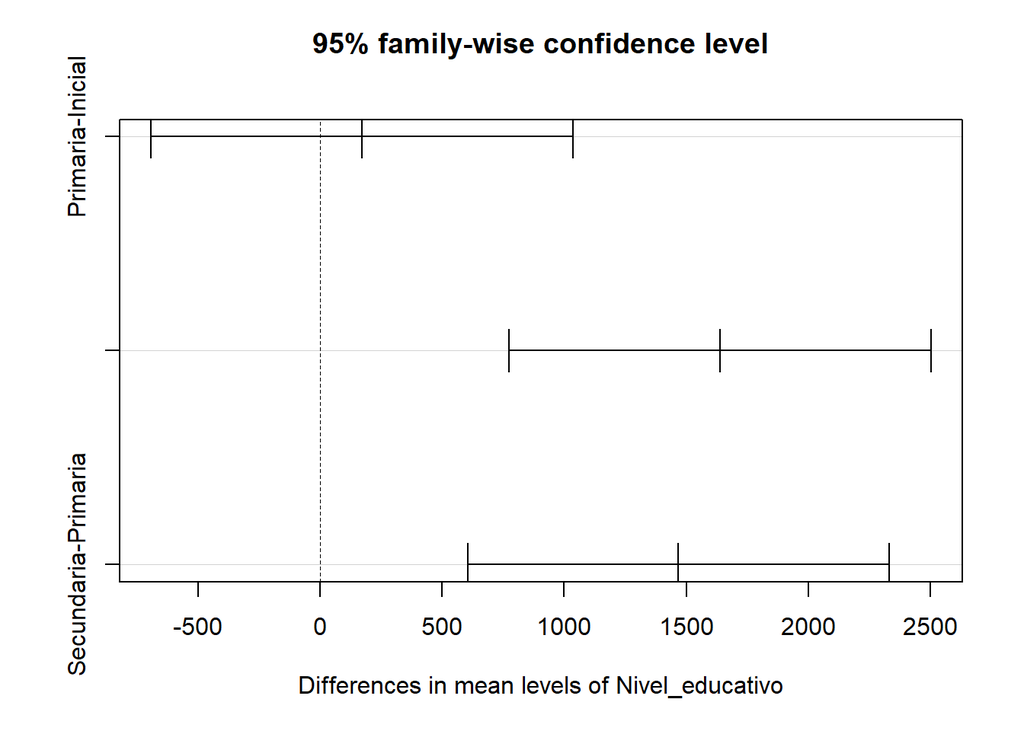

##### Supuestos

**Normalidad de residuos**

Debido a que el p-value (0.003779) es menor al nivel de significancia (0.05) podemos concluir que no se cumple el supuesto de normalidad de los residuos.

```
##
##  Shapiro-Wilk normality test
##
## data:  residuo_Shapiro
## W = 0.94958, p-value = 0.003779
```

**Homogeneidad de varianzas**

Debido a que el p-value (0.003535) es menor al nivel de significancia (0.05) podemos concluir que no se cumple el supuesto de homoneidad de varianzas

```
Bartlett test of homogeneity of variances
```

data: Gasto by Nivel educativo Bartlett’s K-squared = 11.29, df = 2, p-value = 0.003535

#### Pruebas Chi-cuadrado

El responsable de la Dirección de Planificación Presupuestaría para Educación Básica del MEF desea saber si existe alguna relación entre el sexo del estudiante y el nivel educativo

- Planteamiento de hipótesis

Ho: No existe alguna relación entre el sexo del estudiante y el nivel educativo

H1: Existe alguna relación entre el sexo del estudiante y el nivel educativo

- Nivel de sinificancia

alfa = 0.05

- Estadístico de prueba:

Chi2 = 0.1616

- Decisión estadística:

p-value = 0.9224 > 0.05 = alfa; No se rechaza Ho

- Conclusión estadística:

A un nivel de significancia de 5% no se puede afirmar que existe alguna relación entre el sexo del estudiante y el nivel educativo

Distribución de estudiantes de educación según nivel educativo y sexo

|  | Masculino | Femenino | Total |
| --- | --- | --- | --- |
| Inicial | 12 | 14 | 26 |
| Primaria | 15 | 16 | 31 |
| Secundaria | 17 | 22 | 39 |
| Total | 44 | 52 | 96 |

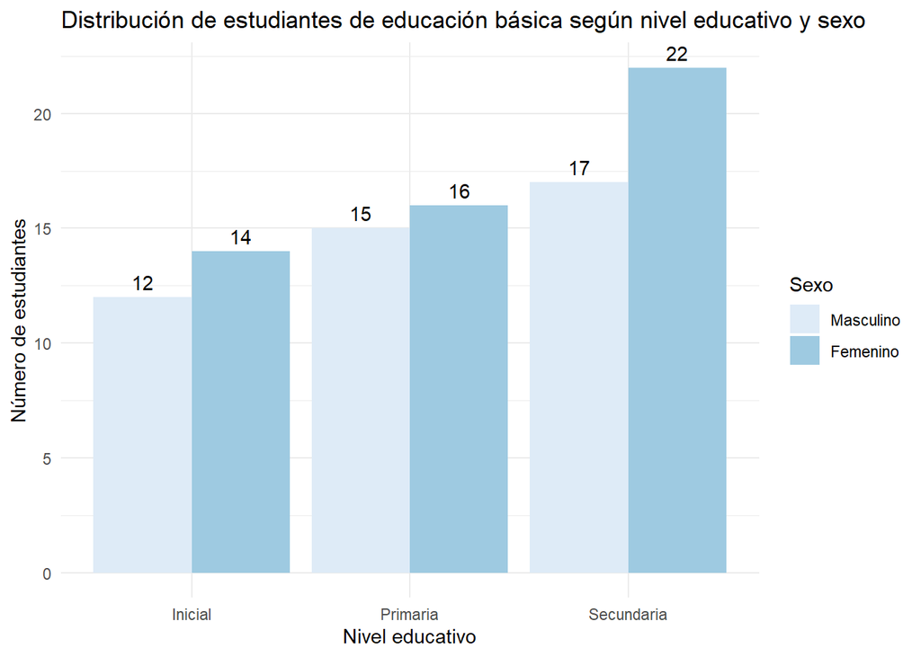

```
Pearson's Chi-squared test
```

data: tabla X-squared = 0.16159, df = 2, p-value = 0.9224

### Regresión lineal

El responsable de la Dirección de Planificación Presupuestaría para Educación Básica del MEF desea realizar un análisis de regresión y correlación entre la variable gasto anual en tecnología por estudiantes en función del gasto anual en educación.

**Diagrama de dispersión**

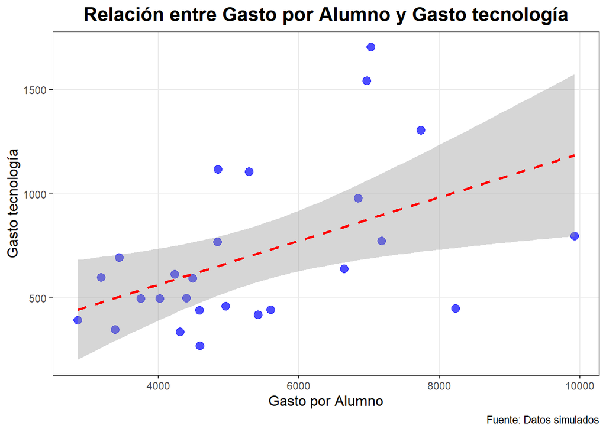

**Resumen del modelo**

```
##
## Call:
## lm(formula = gasto_tecnologia ~ Gasto_2022, data = datos_2022_secundaria_reg)
##
## Residuals:
##     Min      1Q  Median      3Q     Max
## -555.99 -201.76  -59.15  119.79  822.26
##
## Coefficients:
##              Estimate Std. Error t value Pr(>|t|)
## (Intercept) 145.15325  215.37441   0.674   0.5068
## Gasto_2022    0.10484    0.03843   2.728   0.0117 *
## ---
## Signif. codes:  0 '***' 0.001 '**' 0.01 '*' 0.05 '.' 0.1 ' ' 1
##
## Residual standard error: 335.2 on 24 degrees of freedom
## Multiple R-squared:  0.2367, Adjusted R-squared:  0.2049
## F-statistic: 7.443 on 1 and 24 DF,  p-value: 0.01172
```

** Podemos concluir que el modelo de regresión lineal es válido (p-value = 0.0117 < 0.05 = alfa)

** Por cada sol de gasto anual en educación el gasto en tecnología se incrementa en 0.105 soles

** La variabilidad de gasto en tecnología es explicada en un 23.67% por el modelo de regresión lineal

##### Supuestos

**Normalidad de residuos**

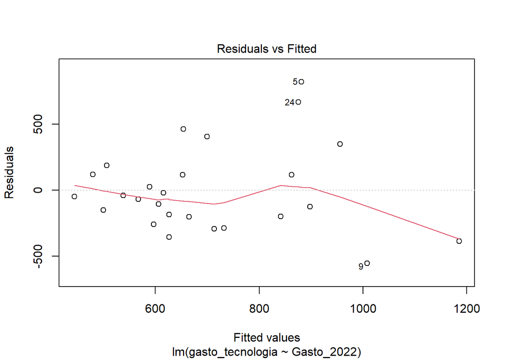

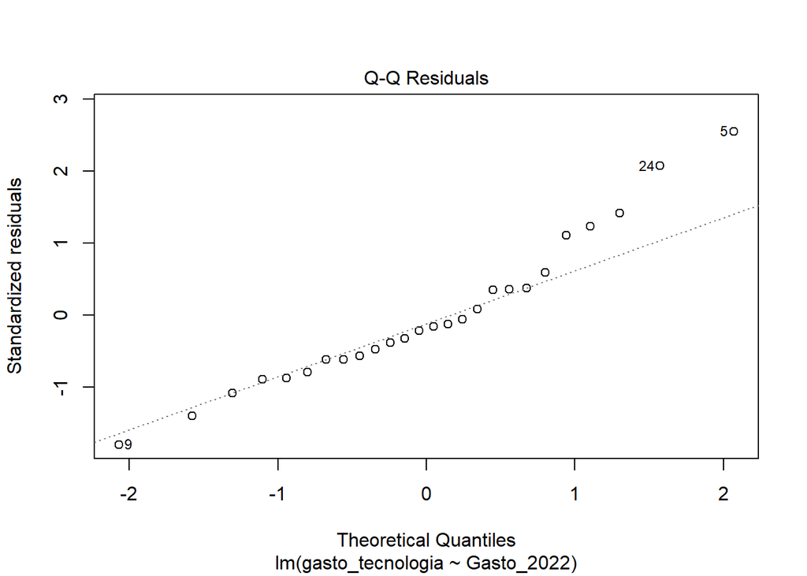

```
##
##  Shapiro-Wilk normality test
##
## data:  residuals(ajuste_reg)
## W = 0.94452, p-value = 0.1721
```

Se concluye que los residuos se distribuyen normalmente (p-value = 0.1721 > 0.05 = alfa)

**Homocedasticidad de residuos**

```
##
##  studentized Breusch-Pagan test
##
## data:  ajuste_reg
## BP = 6.2366, df = 1, p-value = 0.01251
```

Se concluye que los residuos no presentan homocedasticidad (p-value = 0.01251 < 0.05 = alfa)